# Data Visualization

## 4. Colour, size and shapes

There are two main ways we can change the shapes of points and their colour. The first would be to add a single fixed colour and shape. The full list of these "aesthetics" can be looked up [here](https://ggplot2.tidyverse.org/articles/ggplot2-specs.html).

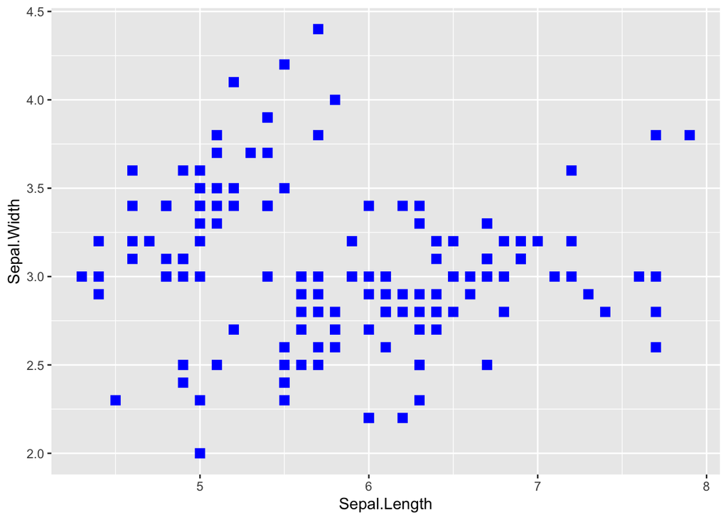

```r
iris  %>%
  ggplot(mapping=aes(x=Sepal.Length, y=Sepal.Width)) +
    geom_point(color="blue", shape="square", size=3)
```

However, the full power of shapes or colours is to distinguish between groups of data. Instead of defining these as fixed variables, we can include them as *mapping variables*. This time, we don't specify a specific shape or colour, but we assign variables to these components:

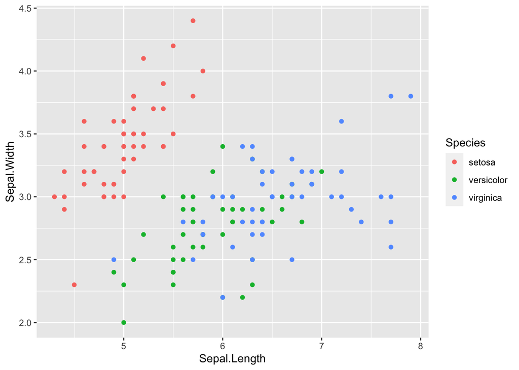

```r
iris  %>%
  ggplot(mapping=aes(x=Sepal.Length, y=Sepal.Width)) +
    geom_point(mapping=aes(color=Species))
```

## 4. Adding more layers

Next, we may want to manipulate the scale, the colour choices or any other aspect of the plot. The possibilities are quite extensive, and in my opinion, are best learned on the go. For now lets just look at some of them.

#### Scales

There are many scales. Start typing `scales_` and have a look at the options. For now, lets manually define the colours and change the axis ticks. Note that we are also going to touch on [hex colour codes](https://htmlcolorcodes.com/).

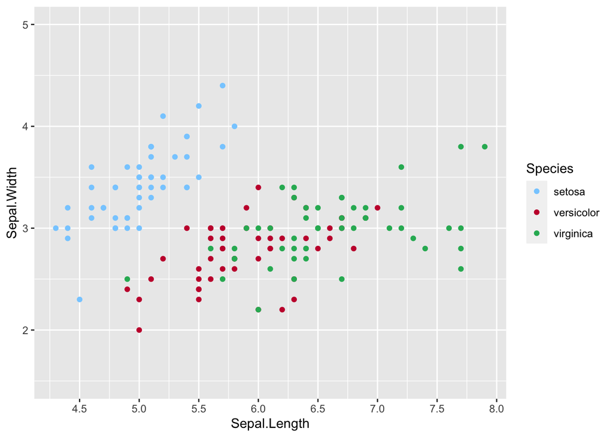

```r
iris  %>%
  ggplot(mapping=aes(x=Sepal.Length, y=Sepal.Width)) +
  geom_point(mapping=aes(color=Species)) +
  scale_colour_manual(values = c(setosa="skyblue1", versicolor="#c70039", virginica="#28b463")) +
  scale_x_continuous(n.breaks = 10) +
  scale_y_continuous(limits = c(1.5,5))
```

#### Titles, axes and legends

There are many ways that plots can be customized.. lets look at some of them:

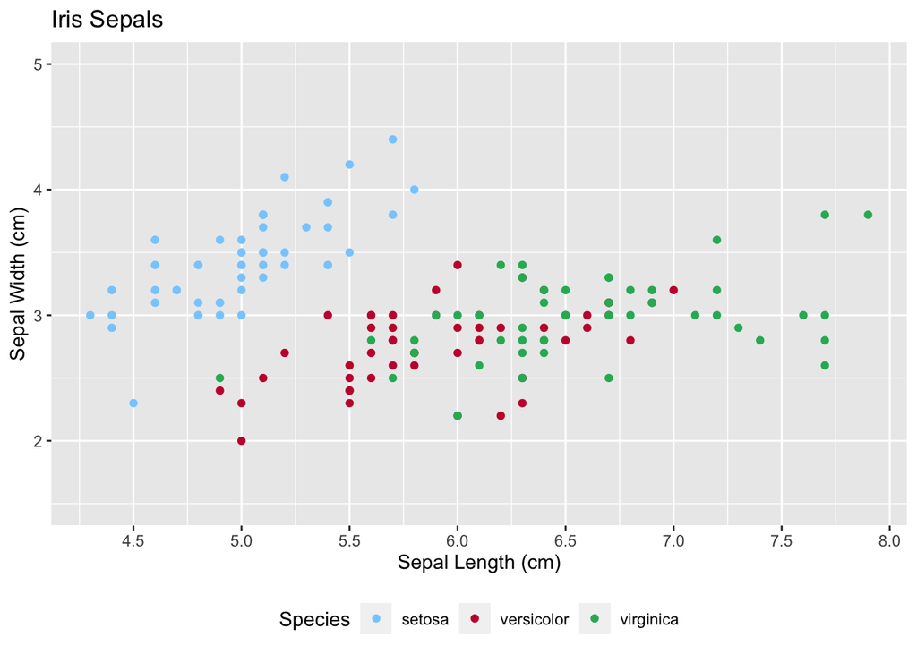

```r
iris  %>%
  ggplot(mapping=aes(x=Sepal.Length, y=Sepal.Width)) +
  geom_point(mapping=aes(color=Species)) +
  scale_colour_manual(values = c(setosa="skyblue1", versicolor="#c70039", virginica="#28b463")) +
  scale_x_continuous(n.breaks = 10) +
  scale_y_continuous(limits = c(1.5,5)) +
  labs(x="Sepal Length (cm)", y="Sepal Width (cm)") +
  ggtitle("Iris Sepals") +
  theme(legend.position="bottom")
```

Lets try one of them:

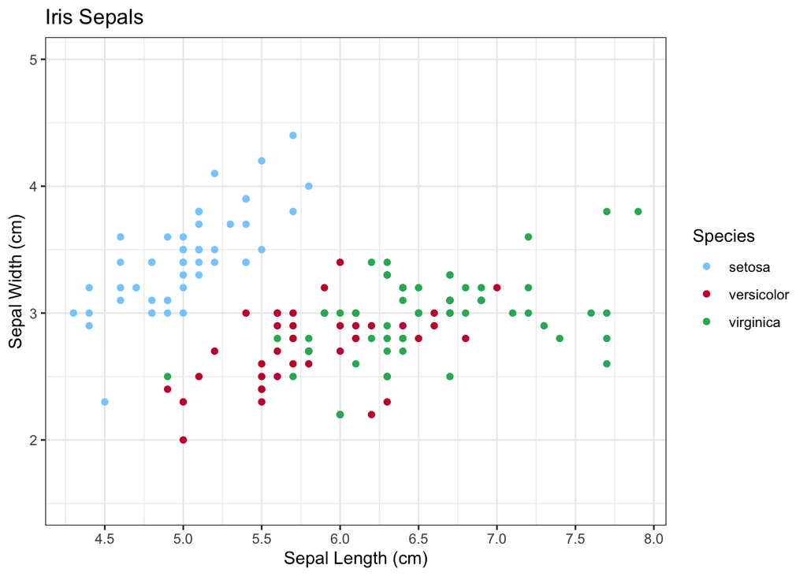

```r
iris  %>%
  ggplot(mapping=aes(x=Sepal.Length, y=Sepal.Width)) +
  geom_point(mapping=aes(color=Species)) +
  scale_colour_manual(values = c(setosa="skyblue1", versicolor="#c70039", virginica="#28b463")) +
  scale_x_continuous(n.breaks = 10) +
  scale_y_continuous(limits = c(1.5,5)) +
  labs(x="Sepal Length (cm)", y="Sepal Width (cm)") +
  ggtitle("Iris Sepals") +
  theme_bw()
```

#### Regression lines

We can also add regression lines to our plots with relative ease. This is also a good time to demonstrate how mapping variables are inherited.

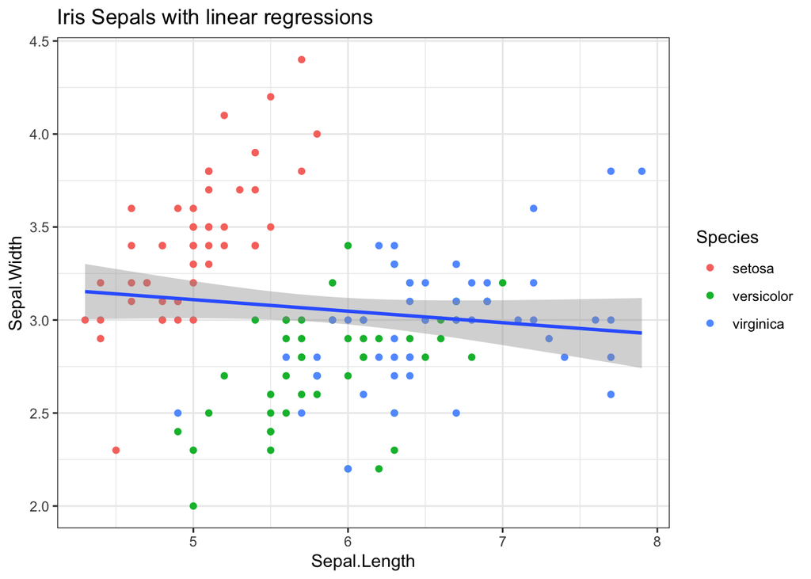

```r
# a single regression slope
iris  %>%
  ggplot(mapping=aes(x=Sepal.Length, y=Sepal.Width)) +
  geom_point(mapping=aes(color=Species)) +
  geom_smooth(method = "lm") +
  ggtitle("Iris Sepals with linear regressions") +
  theme_bw()
```

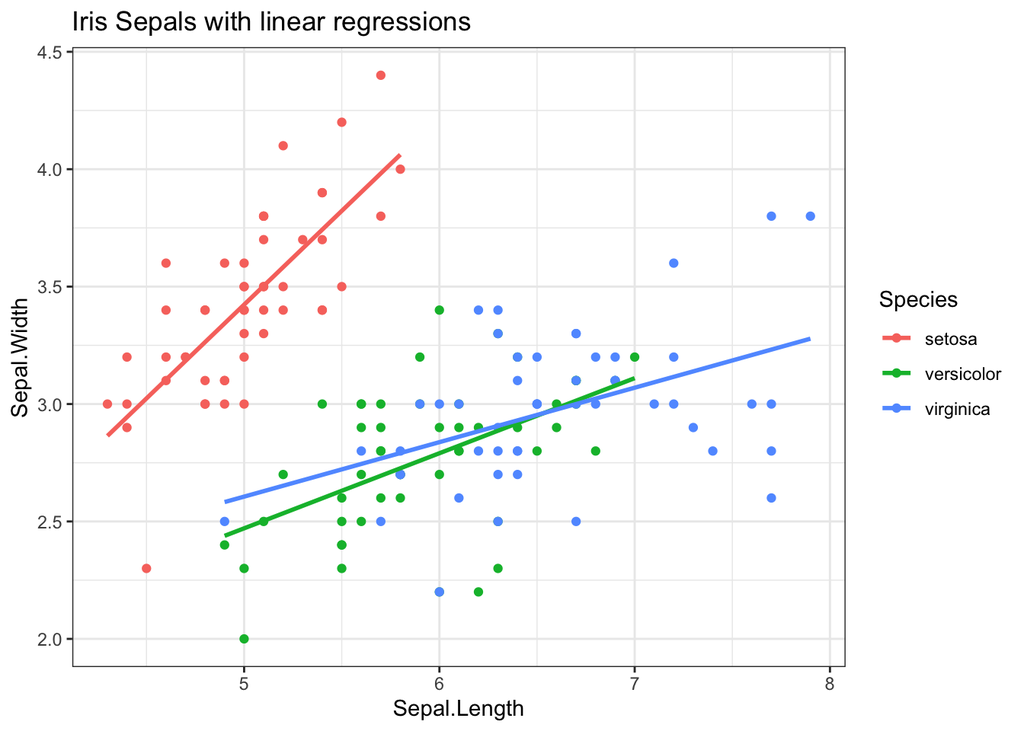

```r
# multiple regression slopes
iris  %>%
  ggplot(mapping=aes(x=Sepal.Length, y=Sepal.Width, color=Species)) +
  geom_point() +
  geom_smooth(method = "lm", se=FALSE) +
  ggtitle("Iris Sepals with linear regressions") +
  theme_bw()
```

## 5. Faceting

Another very powerful method for plotting data is *faceting*. This refers to splitting related data across multiple plots. For example, with the iris data, we could plot each species across a different plotting area, because they share the same axes.

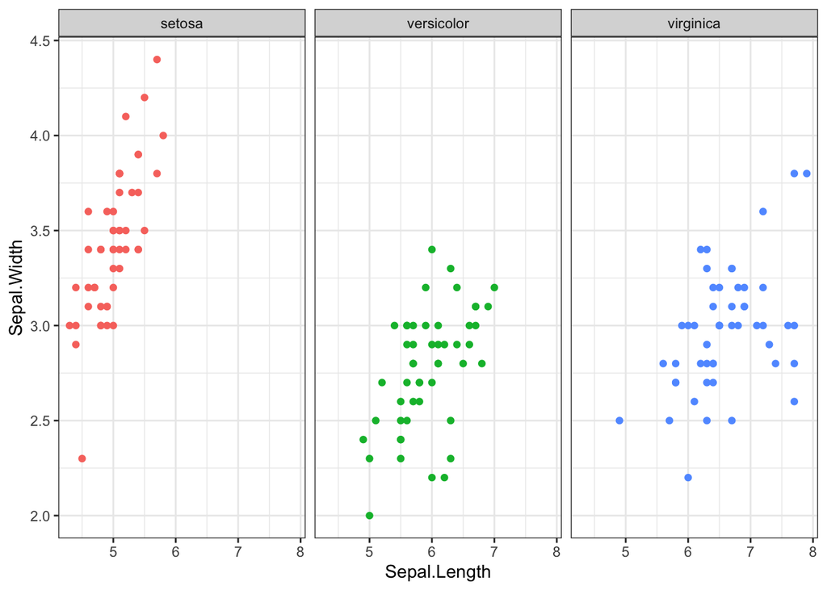

```r
iris  %>%
  ggplot(mapping=aes(x = Sepal.Length, y = Sepal.Width, color = Species)) +  # note, we have included the mapping variables here, not for the geom_point()
  geom_point() +
  facet_wrap( ~ Species, nrow = 1, scales = "fixed") + # play arund with the number of rows and the scales!
  theme_bw() +
  theme(legend.position = "none") # we don't need the legend anymore.
```

## 6. Different types of plots

So far, we have only looked at scatter plots, but by simply switching out the *geometry* we can change the type of plot we want.

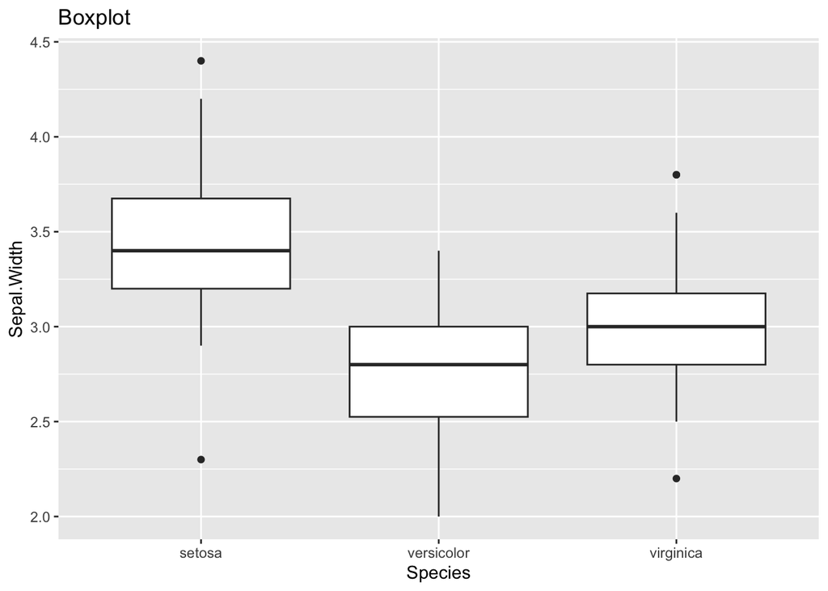

```r
iris  %>%
  ggplot(mapping=aes(x = Species, y = Sepal.Width)) +
  geom_boxplot() +
  ggtitle("Boxplot")
```

Or we can combine geometries

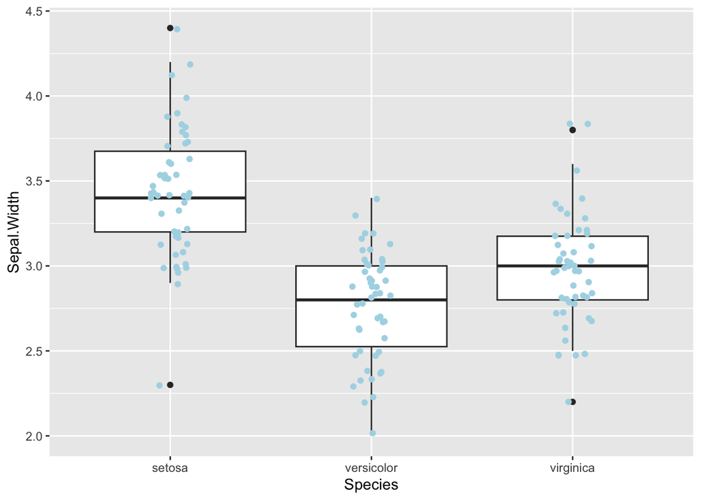

```r
iris  %>%
  ggplot(mapping=aes(x = Species, y = Sepal.Width)) +
  geom_boxplot() +
  geom_jitter(width=0.1, color="lightblue")
```

or densities/ histogram:

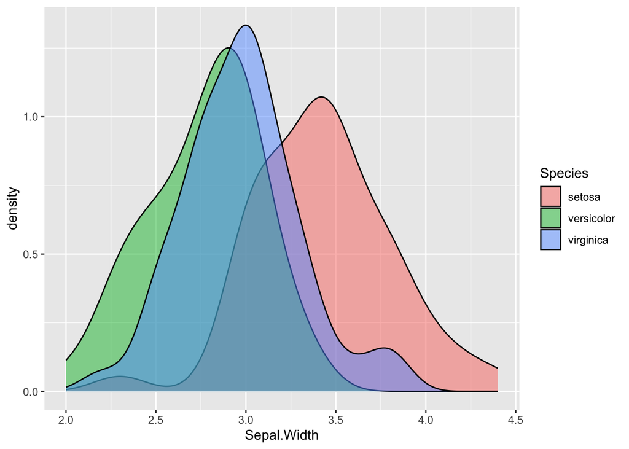

```r
iris  %>%
  ggplot(mapping=aes(x = Sepal.Width, fill=Species)) +
  geom_density(alpha=0.5) # try swapping this out for geom_histogram()
```

or bar plots on a summary statistic.

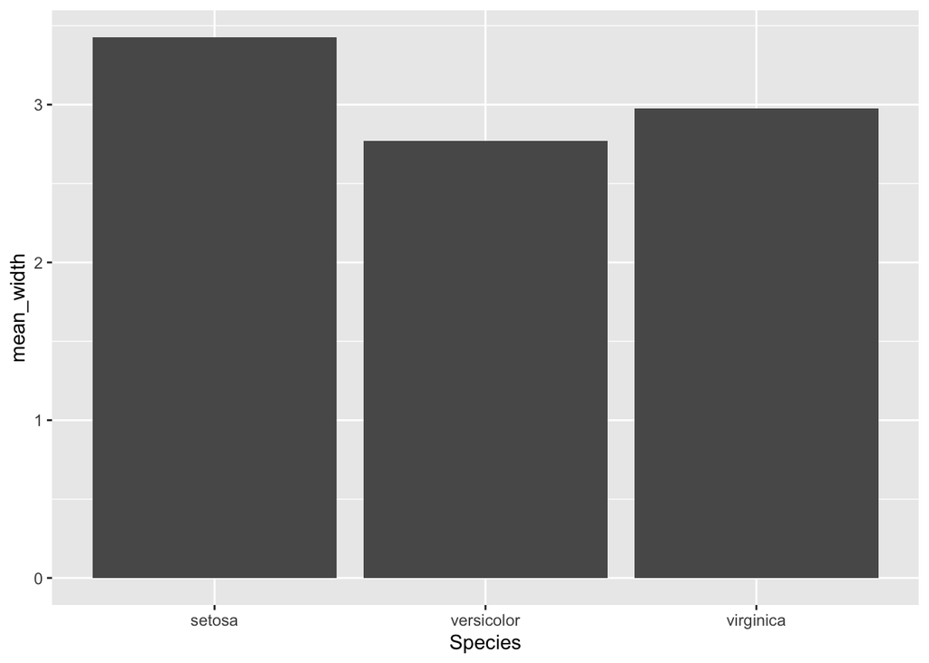

```r
## by calculating summary statistic first
iris %>%
  group_by(Species) %>%
  summarise(mean_width=mean(Sepal.Width)) %>%
  ggplot(aes(x=Species, y=mean_width)) +
  geom_bar(stat="identity")
```

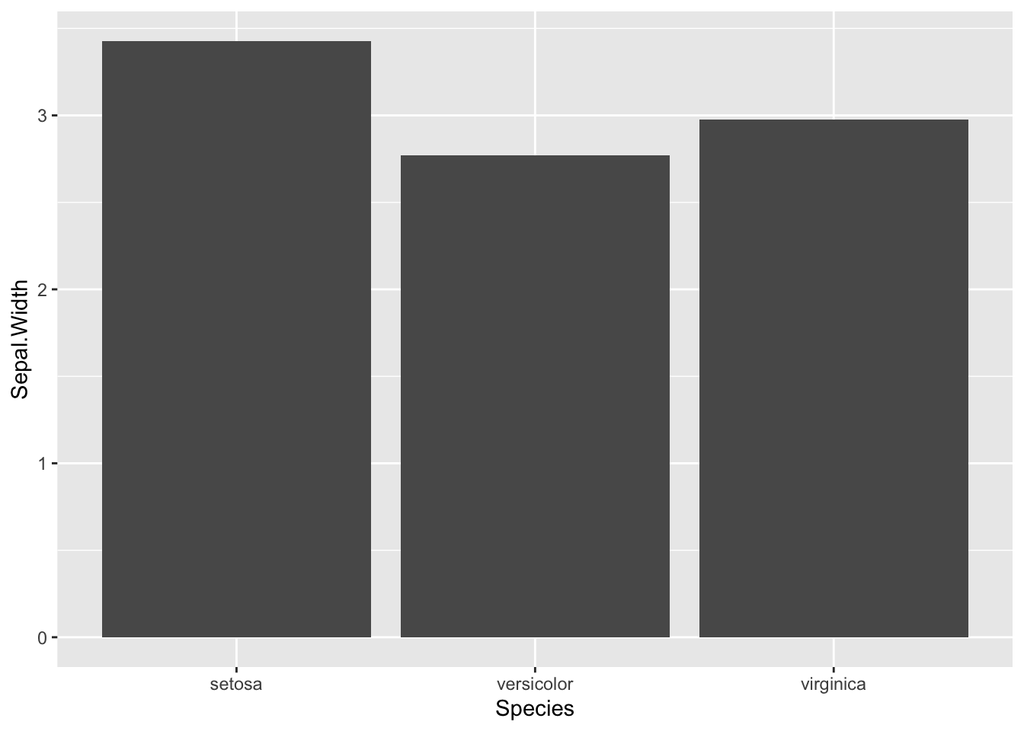

```r
# by using stat_summary()
iris %>%
  ggplot(aes(x=Species, y=Sepal.Width)) +
  stat_summary(fun.y="mean",geom="bar")
```

## 7. Exporting plots

Once you have your plot ready, you will want to export it. The easiest way to do this is to use the "Export" menu in the Plots window.

In almost all cases, your plots will be some form of vectorized graphic.

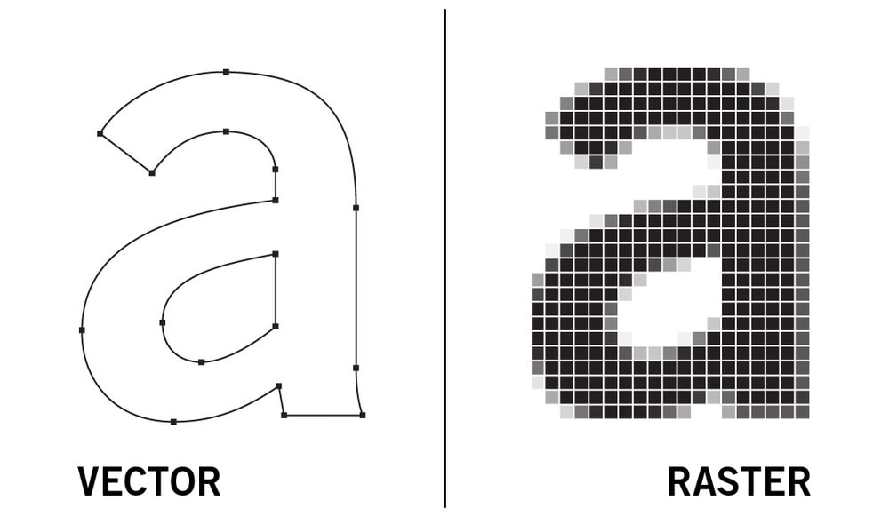

[image source](https://blog.fileformat.com/image/raster-vs-vector-images-a-brief-comparison/)

For this reason, it is almost always the better choice to export plots as PDFs that support vector graphics. This will insure no resolution is lost and it would give you the option to edit minor aspects post-plotting, in software such as [Adobe Illustrator](https://www.adobe.com/products/illustrator.html), or free alternatives like [figma](https://www.figma.com/) or [GIMP](https://www.gimp.org/).

# Sources

This tutorial borrowed code and ideas from the following sources:

https://ggplot2-book.org/introduction